# Working with count compositional data

SK

2023-06-15

# Introduction

Dirichlet multinomial (DM) distribution is a compound probability distribution, where a probability vector $\theta$ is drawn from a Dirichlet distribution with parameter vector $\alpha$ and an observation data (counts; $y$) drawn from a multinomial distribution with probability vector $\theta$ and total number of trials $n$. The Dirichlet prior - the vector $\alpha\in\mathbb{R}^{+}$, can be seen as **pseudo**count:

- $y \sim \mathrm{Multinomial}(\theta, n)$
- $\theta \sim \mathrm{Dirichlet}(\alpha)$
- $\alpha = \ldots$

Crash course on Dirichlet and Multinomial distributions: https://ixkael.github.io/dirichlet-multinomial-conjugate-priors/

# Lets simulate data from DM distribution

Here I assume we have samples obtained from a number of patients before and after treatment with a drug. Each sample measures the mRNA abundances (**counts**) of $K$ genes (categories). Hence, sample $i$ is represented by K-vector $\vec{y}_{i}=\{y_{i1},y_{i2},\ldots,y_{ik}\}$.

For patient $i$ we have two such samples:

- $\vec{y}_i^{b}$: collected before treatment
- $\vec{y}_i^{a}$: collected after treatment

The sum of mRNAs observed in each sample is fixed to $n_i=10^4$, i.e., $n_i=\sum_{j=1}^k y_{ij}=10^4$. We can use the STAN model shown below to simulate data from DM distribution:

- $y \sim \mathrm{Multinomial}(\theta, n)$
- $\theta \sim \mathrm{Dirichlet}(\alpha)$
- $\alpha = \xi\cdot \mathrm{softmax}(\gamma + \beta x)$

where $x$ is a design variable, with $x=1$ for samples before and $x=-1$ for samples after treatment. $\gamma$ is an intercept, $\beta$ represents the effect of the treatment, and $\xi\in\mathbb{R}^{+}$ is precision.

```stan
data {
  int<lower=0> K; // categories (genes)
  vector[K] gamma; // intercept
  vector[K] beta; // effect
  real xi; // precision
  int n; // total counts (tries)
}

generated quantities {
  int y_a [K]; // sample after
  int y_b [K]; // sample before
  vector [K] alpha [2]; // intermediate alphas from dirichlet dist.
  alpha[1] = dirichlet_rng(xi*softmax(gamma + beta)); // before treatment sim. from DM.
  alpha[2] = dirichlet_rng(xi*softmax(gamma - beta)); // after treatment sim. from DM.
  y_a = multinomial_rng(alpha[1], n); // simulate from multinomial dist. -> after sample
  y_b = multinomial_rng(alpha[2], n); // simulate from multinomial dist. -> before sample
}
```

Now we only need to provide the inputs (see data block in the STAN model) to simulate data

```r
set.seed(seed = 12345)
K <- 20
gamma <- rnorm(n = K, mean = 0, sd = 1)
beta <- rnorm(n = K, mean = 0, sd = 0.25)
xi <- 100
n <- 10^4
```

… and simulate 20 samples with:

```r
sim_data <- rstan::sampling(
  object = model_sim,
  data = list(K = K, gamma = gamma, beta = beta, xi = xi, n = n),
  chain = 1,
  cores = 1,
  iter = 20,
  warmup = 0,
  algorithm = "Fixed_param",
  seed = 12345,
  verbose = FALSE,
  refresh = -1)
```

We then extract the simulated observations: two matrices $\vec{y}^{a}$ and $\vec{y}^{b}$, with rows as samples and columns as genes. We treat the first 10 samples (rows in each matrix) as observed/training samples ($D_{\text{train}}$), and we will treat the remaining 10 samples as unobserved/testing sample ($D_{\text{test}}$).

We can visualize the data using ggplot. Each point is the mRNA count (y-axis) for a given gene (x-axis) of a sample (point). Notice the differences in mRNA counts between the two conditions for genes 12, 5, 7, etc. Filled points are train and hollow points are test data.

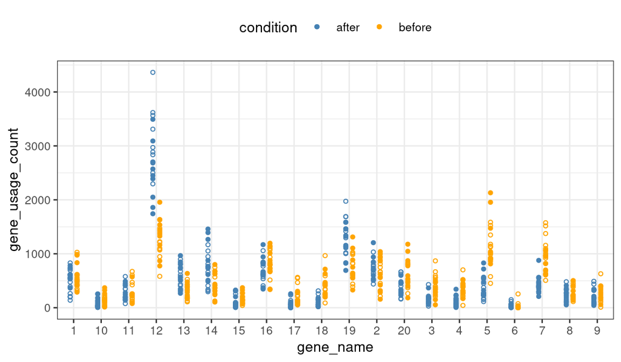

```r
ggplot()+
  geom_point(data = u$proc_ud, aes(x = gene_name, y = gene_usage_count, col = condition),
             position = position_dodge(width = 0.5), size = 1)+
  geom_point(data = u$proc_ud_test, aes(x = gene_name, y = gene_usage_count, col = condition),
             position = position_dodge(width = 0.5), size = 1, shape = 21)+
  theme_bw(base_size = 10)+
  theme(legend.position = "top")+
  scale_color_manual(values = c("steelblue", "orange"))
```

## Modeling

We know that the data was generated from $DM$ distribution. What would happen if we assumed that the data comes from a) multinomial distribution (model $M$) and b) dirichlet multinomial distribution (model $DM$)?

For this we will use two models that I have developed for differential immunoglobulin gene usage (DGU) analysis between pairs of samples. The models have *similar* structure as the model used for data simulation.

The main difference between the simulation model and the DGU models is that the DGU models are hierarchical. They assume that samples within a condition (here condition = “before” vs “after” treatment) are not completely independent from each other, and use partial pooling to enable sharing of information (about parameters) between samples within a condition.

Model $DM$ and $M$ are identical, except for the following differences:

### Model $DM$

- $\vec{y_i} \sim \mathrm{Multinomial}(\vec{\theta_i}, n_i)$
- $\vec{\theta_i} \sim \mathrm{Dirichlet}(\xi \cdot \mathrm{softmax}(\vec{\mu_i}))$
- $\vec{\mu_i} = \vec{\gamma}_i+\vec{\beta}_{i}x$

### Model $M$

- $\vec{y_i} \sim \mathrm{Multinomial}(\vec{\theta_i}, n_i)$
- $\vec{\theta_i} = \mathrm{softmax}(\vec{\mu_i})$
- $\vec{\mu_i} = \vec{\gamma}_i+\vec{\beta}_{i}x$

### STAN code for model $DM$

```stan
functions {
  real dirichlet_multinomial_complete_lpmf(int[] y, vector alpha) {
    real sum_alpha = sum(alpha);
    return lgamma(sum_alpha) - lgamma(sum(y) + sum_alpha)
           + lgamma(sum(y)+1) - sum(lgamma(to_vector(y)+1))
           + sum(lgamma(to_vector(y) + alpha)) - sum(lgamma(alpha));
  }
}

data {
  int <lower = 0> N_sample; // number of samples (repertoires)
  int <lower = 0> N_gene; // number of genes
  int Y_1 [N_gene, N_sample]; // number of successes (cells) in samples x gene
  int Y_2 [N_gene, N_sample]; // number of successes (cells) in samples x gene
  int N [N_sample, 2]; // number of total tries (repertoire size)
  // test data
  int <lower = 0> N_sample_test; // number of samples (repertoires)
  int Y_1_test [N_gene, N_sample_test]; // number of successes (cells) in samples x gene
  int Y_2_test [N_gene, N_sample_test]; // number of successes (cells) in samples x gene
  int N_test [N_sample_test, 2]; // number of total tries (repertoire size)
}

transformed data {
  real N_real [N_sample, 2];
  N_real = N;
}

parameters {
  vector [N_gene] alpha_mu_gene;
  real <lower=0> beta_sigma_gene;
  real <lower=0> alpha_sigma_gene;
  real <lower=0> beta_sigma_pop;
  vector [N_gene] beta_z [N_sample];
  vector [N_gene] alpha_z [N_sample];
  vector [N_gene] beta_z_gene;
  real <lower=0> xi;
}

transformed parameters {
  vector [N_gene] alpha [N_sample];
  vector [N_gene] beta [N_sample];
  vector [N_gene] beta_mu_gene;

  beta_mu_gene = 0+beta_sigma_pop*beta_z_gene;
  for(i in 1:N_sample) {
    beta[i] = beta_mu_gene + beta_sigma_gene * beta_z[i];
    alpha[i] = alpha_mu_gene + alpha_sigma_gene * alpha_z[i];
  }
}

model {
  target += exponential_lpdf(xi | 0.05);
  target += cauchy_lpdf(beta_sigma_pop | 0, 1);
  target += cauchy_lpdf(alpha_sigma_gene | 0, 1);
  target += cauchy_lpdf(beta_sigma_gene | 0, 1);
  for(i in 1:N_sample) {
    target += normal_lpdf(alpha_z[i] | 0, 1);
    target += normal_lpdf(beta_z[i] | 0, 1);
  }
  target += normal_lpdf(beta_z_gene | 0, 1);
  target += normal_lpdf(alpha_mu_gene | 0, 5);

  // likelihood
  for(i in 1:N_sample) {
    target += dirichlet_multinomial_complete_lpmf(Y_1[,i]|xi * softmax(alpha[i]-beta[i]));
    target += dirichlet_multinomial_complete_lpmf(Y_2[,i]|xi * softmax(alpha[i]+beta[i]));
  }
}

generated quantities {
  int Y_hat_1 [N_gene, N_sample];
  int Y_hat_2 [N_gene, N_sample];
  int Y_hat_group_1 [N_gene, N_sample];
  int Y_hat_group_2 [N_gene, N_sample];
  real log_lik [N_sample, 2];
  real log_lik_train [N_sample, 2];
  real log_lik_test [N_sample_test, 2];

  vector [N_gene] mu [2];
  real a [N_gene];
  real b [N_gene];

  for(i in 1:N_sample) {
    mu[1] = dirichlet_rng(xi * softmax(alpha[i]-beta[i]));
    Y_hat_1[,i] = multinomial_rng(mu[1], N[i,1]);
    mu[2] = dirichlet_rng(xi * softmax(alpha[i]+beta[i]));
    Y_hat_2[,i] = multinomial_rng(mu[2], N[i,2]);

    log_lik[i,1] = dirichlet_multinomial_complete_lpmf(Y_1[,i]|xi*softmax(alpha[i]-beta[i]));
    log_lik[i,2] = dirichlet_multinomial_complete_lpmf(Y_2[,i]|xi*softmax(alpha[i]+beta[i]));
  }

  // PPC: condition-specific
  a = normal_rng(alpha_mu_gene, alpha_sigma_gene);
  b = normal_rng(beta_mu_gene, beta_sigma_gene);
  mu[1] = xi * softmax(to_vector(a)-to_vector(b));
  mu[2] = xi * softmax(to_vector(a)+to_vector(b));
  // PPC: test
  for(i in 1:N_sample_test) {
    log_lik_test[i,1] = dirichlet_multinomial_complete_lpmf(Y_1_test[,i]|mu[1]);
    log_lik_test[i,2] = dirichlet_multinomial_complete_lpmf(Y_2_test[,i]|mu[2]);
  }
  // PPC: train
  for(i in 1:N_sample) {
    log_lik_train[i,1] = dirichlet_multinomial_complete_lpmf(Y_1[,i]|mu[1]);
    log_lik_train[i,2] = dirichlet_multinomial_complete_lpmf(Y_2[,i]|mu[2]);
    Y_hat_group_1[,i] = multinomial_rng(dirichlet_rng(mu[1]), N[i,1]);
    Y_hat_group_2[,i] = multinomial_rng(dirichlet_rng(mu[2]), N[i,2]);
  }
}
```

### STAN code for model $M$

```stan
data {
  int <lower = 0> N_sample; // number of samples (repertoires)
  int <lower = 0> N_gene; // number of genes
  int Y_1 [N_gene, N_sample]; // number of successes (cells) in samples x gene
  int Y_2 [N_gene, N_sample]; // number of successes (cells) in samples x gene
  int N [N_sample, 2]; // number of total tries (repertoire size)
  // test data
  int <lower = 0> N_sample_test; // number of samples (repertoires)
  int Y_1_test [N_gene, N_sample_test]; // number of successes (cells) in samples x gene
  int Y_2_test [N_gene, N_sample_test]; // number of successes (cells) in samples x gene
  int N_test [N_sample_test, 2]; // number of total tries (repertoire size)
}

transformed data {
  real N_real [N_sample, 2];
  N_real = N;
}

parameters {
  vector [N_gene] alpha_mu_gene;
  real <lower=0> beta_sigma_gene;
  real <lower=0> alpha_sigma_gene;
  real <lower=0> beta_sigma_pop;
  vector [N_gene] beta_z [N_sample];
  vector [N_gene] alpha_z [N_sample];
  vector [N_gene] beta_z_gene;
}

transformed parameters {
  vector [N_gene] alpha [N_sample];
  vector [N_gene] beta [N_sample];
  vector [N_gene] beta_mu_gene;

  beta_mu_gene = 0+beta_sigma_pop*beta_z_gene;
  for(i in 1:N_sample) {
    beta[i]=beta_mu_gene+beta_sigma_gene*beta_z[i];
    alpha[i]=alpha_mu_gene+alpha_sigma_gene*alpha_z[i];
  }
}

model {
  target += cauchy_lpdf(beta_sigma_pop | 0, 1);
  target += cauchy_lpdf(alpha_sigma_gene | 0, 1);
  target += cauchy_lpdf(beta_sigma_gene | 0, 1);
  for(i in 1:N_sample) {
    target += normal_lpdf(alpha_z[i] | 0, 1);
    target += normal_lpdf(beta_z[i] | 0, 1);
  }
  target += normal_lpdf(beta_z_gene | 0, 1);
  target += normal_lpdf(alpha_mu_gene | 0, 5);

  // likelihood
  for(i in 1:N_sample) {
    target += multinomial_lpmf(Y_1[,i] | softmax(alpha[i]-beta[i]));
    target += multinomial_lpmf(Y_2[,i] | softmax(alpha[i]+beta[i]));
  }
}

generated quantities {
  int Y_hat_1 [N_gene, N_sample];
  int Y_hat_2 [N_gene, N_sample];
  int Y_hat_group_1 [N_gene, N_sample];
  int Y_hat_group_2 [N_gene, N_sample];
  real log_lik [N_sample, 2];
  real log_lik_test [N_sample_test, 2];
  real log_lik_train [N_sample, 2];

  vector [N_gene] mu [2];
  real a [N_gene];
  real b [N_gene];

  // PPC
  for(i in 1:N_sample) {
    mu[1] = softmax(alpha[i] - beta[i]);
    mu[2] = softmax(alpha[i] + beta[i]);

    Y_hat_1[,i] = multinomial_rng(mu[1], sum(Y_1[,i]));
    Y_hat_2[,i] = multinomial_rng(mu[2], sum(Y_2[,i]));
    log_lik[i,1] = multinomial_lpmf(Y_1[,i] | mu[1]);
    log_lik[i,2] = multinomial_lpmf(Y_2[,i] | mu[2]);
  }

  // PPC - test (condition-specific)
  a = normal_rng(alpha_mu_gene, alpha_sigma_gene);
  b = normal_rng(beta_mu_gene, beta_sigma_gene);
  mu[1]=softmax(to_vector(a)-to_vector(b));
  mu[2]=softmax(to_vector(a)+to_vector(b));
  for(i in 1:N_sample_test) {
    log_lik_test[i,1] = multinomial_lpmf(Y_1_test[,i]|mu[1]);
    log_lik_test[i,2] = multinomial_lpmf(Y_2_test[,i]|mu[2]);
  }
  for(i in 1:N_sample) {
    log_lik_train[i,1] = multinomial_lpmf(Y_1[,i]|mu[1]);
    log_lik_train[i,2] = multinomial_lpmf(Y_2[,i]|mu[2]);
    Y_hat_group_1[,i] = multinomial_rng(mu[1], N[i,1]);
    Y_hat_group_2[,i] = multinomial_rng(mu[2], N[i,2]);
  }
}
```

### Model fitting

We will fit models $DM$ and $M$ using $D_{\text{train}}$.

```r
fit_dm <- rstan::sampling(object = model_dm,
                          data = u,
                          chains = 5,
                          cores = 5,
                          iter = 3500,
                          warmup = 1500,
                          control = list(adapt_delta = 0.99,
                                         max_treedepth = 14),
                          algorithm = "NUTS")
```

```r
fit_m <- rstan::sampling(object = model_m,
                         data = u,
                         chains = 5,
                         cores = 5,
                         iter = 3500,
                         warmup = 1500,
                         control = list(adapt_delta = 0.99, max_treedepth = 14),
                         algorithm = "NUTS")
```

## Posterior predictive checks for each sample

We will use the parameters at the lowest level of the models, which are sample specific parameters, to generate new data. These predictions (means and 95% HDIs) will be compared against the observed data.

Please consider the narrow predictions by model $M$ compared to $DM$.

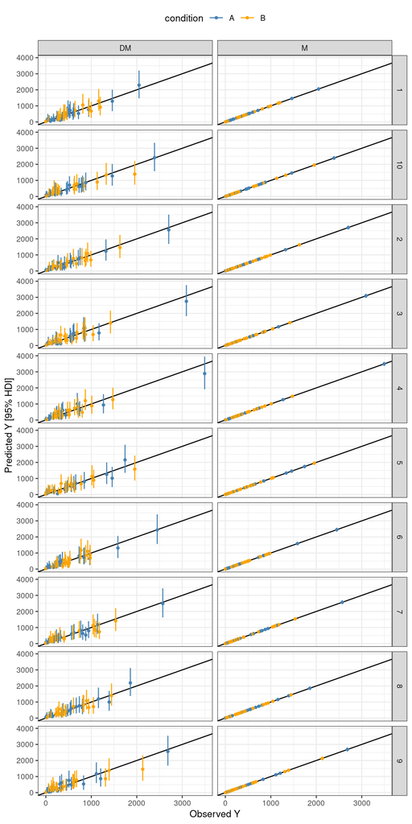

```r
ggplot(data = ppc)+
  geom_abline(slope = 1, intercept = 0)+
  facet_grid(sample_id~model_name)+
  geom_point(aes(y = mean, x = Y, col = condition), size = 1)+
  geom_errorbar(aes(y = mean, x = Y, ymin = X2.5., ymax = X97.5., col = condition))+
  theme_bw(base_size = 10)+
  theme(legend.position = "top")+
  xlab(label = "Observed Y")+
  ylab(label = "Predicted Y [95% HDI]")+
  scale_color_manual(values = c("steelblue", "orange"))
```

Nearly all observations fall within the 95% HDIs of the counts predicted by either model.

```
##
##            DM   M
##   in_hdi  399 400
##   out_hdi   1   0
```

## PPC from condition-specific parameters

To check how well our models predicts new data ($D_{\text{test}}$), we cannot use the sample-specific parameters. For this, we have to use the condition- specific parameters found at the 2nd layer of model structure (see STAN code; generated quantities).

Now, the model $M$ predictions (means and 95% HDIs) are associated with large degree of uncertainty. However, many low count observations are outside the 95% HDIs of the predictions made by model $M$. Model $DM$ does a better prediction overall using its condition-specific parameters.

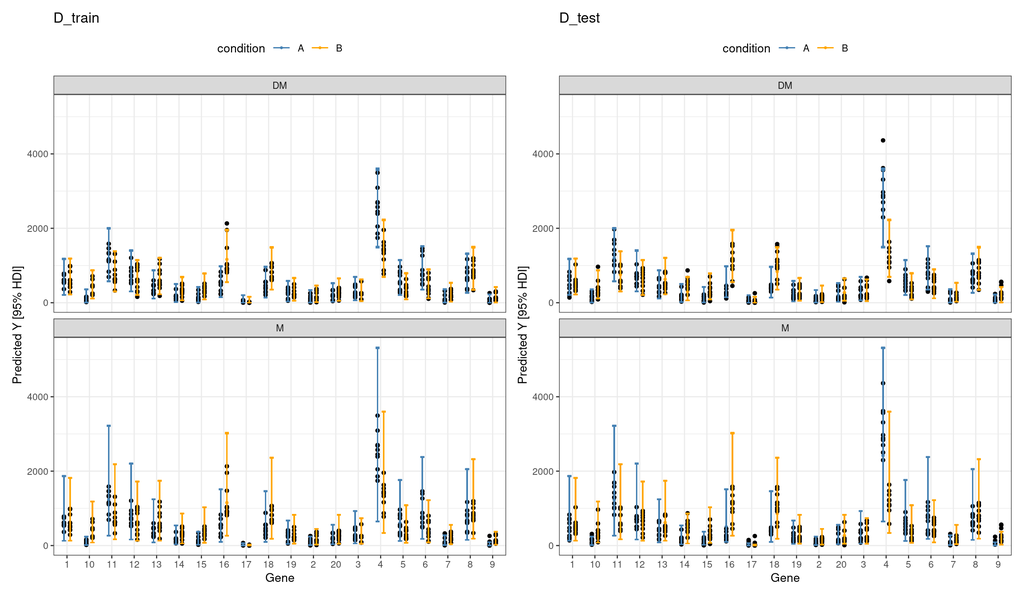

### How many $D_{\text{train}}$ observations are outside the 95% HDIs of the predictions?

Model $DM$ does more meaningful predictions with respect to both $D_{\text{test}}$ and $D_{\text{train}}$.

```
##
##            DM   M
##   in_hdi  391 379
##   out_hdi   9  21
```

### How many $D_{\text{test}}$ observations are outside the 95% HDIs of the predictions?

```
##
##            DM   M
##   in_hdi  376 375
##   out_hdi  24  25
```

## Model comparison with LOO

### with R-package loo (or rstan)

Now, lets turn to LOO with R-package loo. We get many high $k$ diagnostic values. We have too few samples per condition and this is why the approximation fails. Increasing the number of samples to 30 produced mostly “good” and few “ok” k diagnostic values. We should use explicit loo in case of few samples.

Nevertheless, due to the bad approximation we cannot rely on these results.

```
##
## Computed from 10000 by 20 log-likelihood matrix
##
##          Estimate   SE
## elpd_loo  -2415.3 14.1
## p_loo       100.0  5.9
## looic      4830.7 28.3
## ------
## Monte Carlo SE of elpd_loo is NA.
##
## Pareto k diagnostic values:
##                          Count Pct.    Min. n_eff
## (-Inf, 0.5]   (good)      0     0.0%   <NA>
##  (0.5, 0.7]   (ok)        2    10.0%   157
##    (0.7, 1]   (bad)      17    85.0%   12
##    (1, Inf)   (very bad)  1     5.0%   13
## See help('pareto-k-diagnostic') for details.
```

```
##
## Computed from 10000 by 20 log-likelihood matrix
##
##          Estimate   SE
## elpd_loo  -1751.3  7.6
## p_loo       234.1  3.8
## looic      3502.6 15.1
## ------
## Monte Carlo SE of elpd_loo is NA.
##
## Pareto k diagnostic values:
##                          Count Pct.    Min. n_eff
## (-Inf, 0.5]   (good)      0      0.0%  <NA>
##  (0.5, 0.7]   (ok)        0      0.0%  <NA>
##    (0.7, 1]   (bad)       0      0.0%  <NA>
##    (1, Inf)   (very bad) 20    100.0%  1
## See help('pareto-k-diagnostic') for details.
```

## Model comparison with the Widely Applicable Information Criterion (WAIC)

We compute the average log probability ($\text{lppd}$) for observation $y_i$ given posterior draw $s$ of the model parameters ($\Theta$): $\text{lppd}(y,\Theta)=\sum\limits_{i=1}^n\text{log}\dfrac{1}{S}\sum\limits_{s=1}^S \text{Pr}(y_i|\Theta_s)$. Moreover, we compute the effective number of parameters, $p_{\text{eff}}=\sum\limits_{i=1}^n V(y_i)$, where $V(y_i)$ is the variance of the log probability of observation $y_i$. Finally, $\text{WAIC} = -2(\text{lppd}-p_{\text{eff}})$, and we compute $\text{WAIC}$ for $D_{\text{train}}$ and $D_{\text{test}}$ for each model.

### Model $DM$ WAIC

#### $D_{\text{train}}$

Notice that the loo package generated similar estimates:

```
## lppd: -2451.871
```

```
## p_eff: 291.8059
```

```
## WAIC: 5487.354
```

```
## SE of lppd = lppd * sqrt(N) =: 16.51571
```

#### $D_{\text{test}}$

As expected, we see slightly worse (larger) for model $DM$ for $D_{\text{test}}$ compared to $D_{\text{train}}$:

```
## lppd: -2539.485
```

```
## p_eff: 419.1866
```

```
## WAIC: 5917.343
```

```
## SE of lppd = lppd * sqrt(N) =: 21.0186
```

### Model $M$ WAIC

#### $D_{\text{train}}$

```
## lppd: -57066.9
```

```
## p_eff: 24314878
```

```
## WAIC: 48743890
```

```
## SE of lppd = lppd * sqrt(N) =: 1026.864
```

#### $D_{\text{test}}$

However, now have a look at the incredible high (bad) values for $\text{lppd}(D_{\text{test}})$ of model $M$ given $D_{\text{test}}$. We see especially high $p_{\text{eff}}$, which makes sense given the highly variable PPCs.

This indicates overfitting, i.e. model $M$ can predict accurately $D_{\text{train}}$ based on the sample-specific parameters, however, the model does not generalize well to new data.

```
## lppd: -63136.68
```

```
## p_eff: 28509213
```

```
## WAIC: 57144700
```

```
## SE of lppd = lppd * sqrt(N) =: 1553.313
```

# Now the other way around: simulate data from $M$ distribution

```stan
data {
  int<lower=0> K; // categories (genes)
  vector[K] gamma; // intercept
  vector[K] beta; // effect
  int n; // total counts (tries)
}

generated quantities {
  int y_a [K]; // sample after
  int y_b [K]; // sample before
  y_a = multinomial_rng(softmax(gamma + beta), n); // before treatment sim. from M.
  y_b = multinomial_rng(softmax(gamma - beta), n); // after treatment sim. from M.
}
```

```r
set.seed(seed = 12345)
K <- 20
gamma <- rnorm(n = K, mean = 0, sd = 1)
beta <- rnorm(n = K, mean = 0, sd = 0.25)
n <- 10^4
```

```r
sim_data <- rstan::sampling(
  object = model_sim_m,
  data = list(K = K, gamma = gamma, beta = beta, n = n),
  chain = 1,
  cores = 1,
  iter = 20,
  warmup = 0,
  algorithm = "Fixed_param",
  seed = 12345,
  verbose = FALSE,
  refresh = -1)
```

We can visualize the data using ggplot. Each point is the mRNA count (y-axis) for a given gene (x-axis) of a sample (point). Notice the differences in mRNA counts between the two conditions for genes 12, 5, 7, etc. Filled points are train and hollow points are test data.

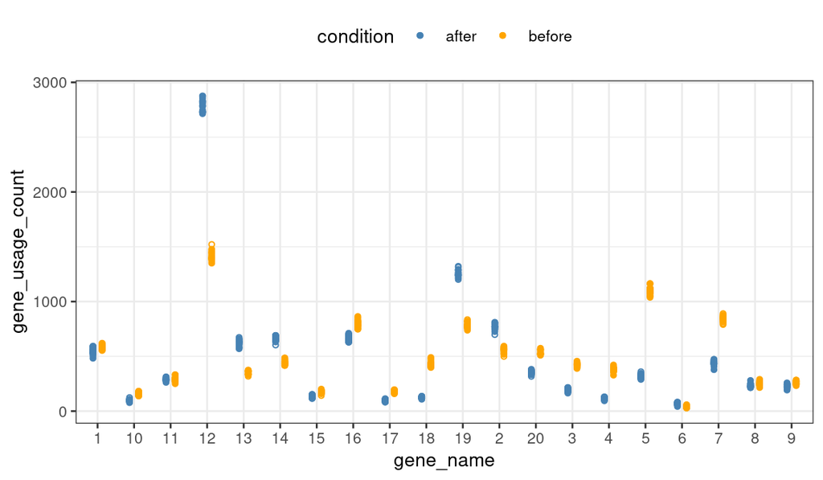

```r
ggplot()+
  geom_point(data = u$proc_ud, aes(x = gene_name, y = gene_usage_count, col = condition),
             position = position_dodge(width = 0.5), size = 1)+
  geom_point(data = u$proc_ud_test, aes(x = gene_name, y = gene_usage_count, col = condition),
             position = position_dodge(width = 0.5), size = 1, shape = 21)+
  theme_bw(base_size = 10)+
  theme(legend.position = "top")+
  scale_color_manual(values = c("steelblue", "orange"))
```

## Modeling

Same models, $DM$ and $M$, as before.

```r
fit_dm <- rstan::sampling(object = model_dm,
                          data = u,
                          chains = 5,
                          cores = 5,
                          iter = 3500,
                          warmup = 1500,
                          control = list(adapt_delta = 0.99, max_treedepth = 14),
                          algorithm = "NUTS")
```

```r
fit_m <- rstan::sampling(object = model_m,
                         data = u,
                         chains = 5,
                         cores = 5,
                         iter = 3500,
                         warmup = 1500,
                         control = list(adapt_delta = 0.99, max_treedepth = 14),
                         algorithm = "NUTS")
```

## Posterior predictive checks for each sample

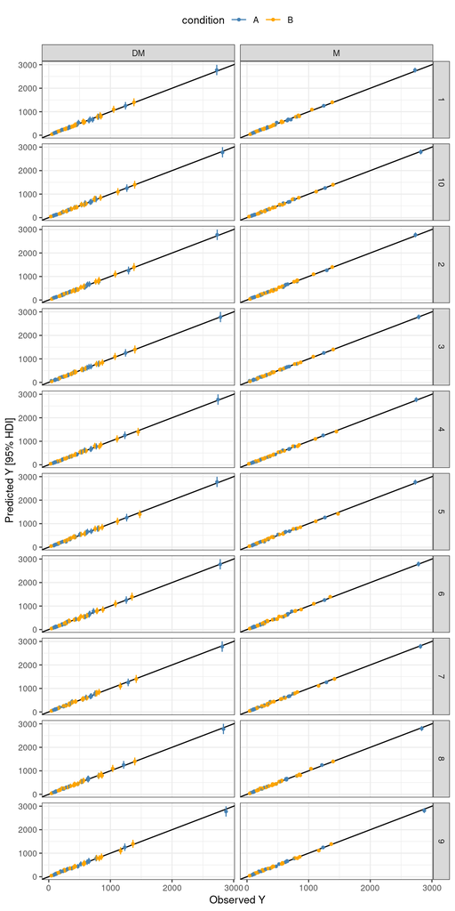

```
##
##            DM   M
##   in_hdi  400 390
##   out_hdi   0  10
```

```r
ggplot(data = ppc)+
  geom_abline(slope = 1, intercept = 0)+
  facet_grid(sample_id~model_name)+
  geom_point(aes(y = mean, x = Y, col = condition), size = 1)+
  geom_errorbar(aes(y = mean, x = Y, ymin = X2.5., ymax = X97.5., col = condition))+
  theme_bw(base_size = 10)+
  theme(legend.position = "top")+
  xlab(label = "Observed Y")+
  ylab(label = "Predicted Y [95% HDI]")+
  scale_color_manual(values = c("steelblue", "orange"))
```

## PPC from condition-specific parameters

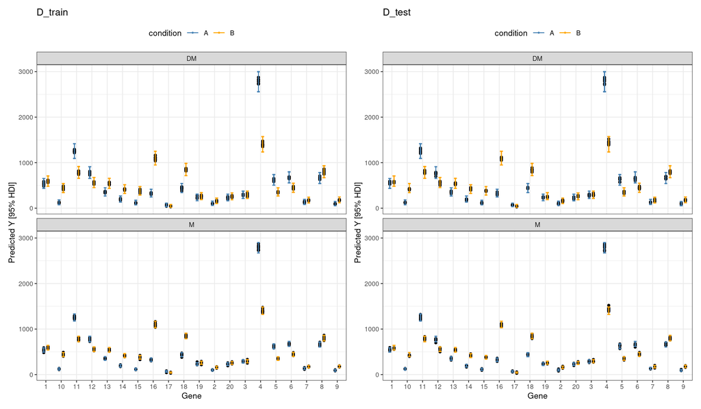

### How many $D_{\text{train}}$ observations are outside the 95% HDIs of the predictions?

```
##
##            DM   M
##   in_hdi  400 388
##   out_hdi   0  12
```

### How many $D_{\text{test}}$ observations are outside the 95% HDIs of the predictions?

```
##
##            DM   M
##   in_hdi  400 385
##   out_hdi   0  15
```

## Model comparison with the Widely Applicable Information Criterion (WAIC)

### Model $DM$ WAIC

#### $D_{\text{train}}$

```
## lppd: -1806.221
```

```
## p_eff: 15.18159
```

```
## WAIC: 3642.805
```

```
## SE of lppd = lppd * sqrt(N) =: 6.042242
```

#### $D_{\text{test}}$

```
## lppd: -1810.233
```

```
## p_eff: 15.83129
```

```
## WAIC: 3652.129
```

```
## SE of lppd = lppd * sqrt(N) =: 5.297119
```

### Model $M$ WAIC

#### $D_{\text{train}}$

```
## lppd: -1661.604
```

```
## p_eff: 112.8095
```

```
## WAIC: 3548.827
```

```
## SE of lppd = lppd * sqrt(N) =: 16.13627
```

#### $D_{\text{test}}$

```
## lppd: -1686.599
```

```
## p_eff: 128.0003
```

```
## WAIC: 3629.198
```

```
## SE of lppd = lppd * sqrt(N) =: 13.51702
```